# Построение моделей регрессии

```python
import dtale
import matplotlib.pyplot as plt
import numpy as np
import optuna
import pandas as pd
import seaborn as sns

from catboost import CatBoostRegressor
from lightgbm import LGBMRegressor
from optuna.samplers import TPESampler

from sklearn.datasets import make_regression
from sklearn.linear_model import Lasso, LinearRegression, Ridge
from sklearn.metrics import mean_squared_error, r2_score
from sklearn.model_selection import cross_val_score, KFold, train_test_split
```

```
<frozen importlib._bootstrap>:228: RuntimeWarning:

numpy.ufunc size changed, may indicate binary incompatibility. Expected 216 from C header, got 232 from PyObject
```

```python
RANDOM_STATE = 42
```

Создадим датасет:

```python
data = make_regression(n_samples = 10000, n_features=100, n_informative=25, noise=0.01, random_state=RANDOM_STATE)
```

Разделим параметры и целевые признаки:

```python
features, target = data
```

```python
features.shape
```

```
(10000, 100)
```

Преобразуем данные в датасет:

```python
df_features = pd.DataFrame(data=features, columns=['col ' + str(i) for i in range(features.shape[1])])
```

```python
df_features.head(5)
```

|  | col 0 | col 1 | col 2 | col 3 | col 4 | col 5 | col 6 | col 7 | col 8 | col 9 | ... | col 90 | col 91 | col 92 | col 93 | col 94 | col 95 | col 96 | col 97 | col 98 | col 99 |
| --- | --- | --- | --- | --- | --- | --- | --- | --- | --- | --- | --- | --- | --- | --- | --- | --- | --- | --- | --- | --- | --- |
| 0 | 0.532439 | 0.641076 | 1.705866 | -1.282963 | 1.440124 | 1.330779 | 1.077244 | 0.220117 | 0.245445 | -1.140127 | ... | -0.798043 | 0.541556 | -0.263779 | 0.546446 | -0.960404 | -1.596718 | 2.197634 | -1.531790 | 0.270997 | -1.747013 |
| 1 | -1.183405 | 0.252357 | 0.365307 | -0.226073 | -1.238925 | -1.156278 | 0.487945 | 0.797485 | -0.357111 | -0.680548 | ... | -1.659618 | -0.593374 | 0.550894 | 0.919185 | 0.913274 | -1.147086 | 0.898427 | -1.769205 | -0.102941 | -0.348496 |
| 2 | 1.743816 | -1.215978 | -1.339327 | 2.112802 | 1.194243 | 1.156293 | 1.393954 | 0.427140 | 0.109166 | -0.088129 | ... | -0.602390 | 0.238784 | 0.792991 | -0.325617 | 0.382134 | 0.170045 | 0.297849 | -0.248335 | 0.953536 | 0.859206 |
| 3 | -0.571303 | -1.302698 | 0.490189 | -2.609239 | -1.007425 | -0.526893 | 0.517243 | -0.522929 | 0.738644 | 1.450757 | ... | -1.497914 | 2.006872 | -1.685710 | -1.382783 | -0.897613 | -1.021491 | -0.521018 | -1.140402 | -0.401211 | 0.045373 |
| 4 | -1.933311 | 0.023362 | 0.357837 | -2.434209 | -1.846628 | 0.581786 | 0.399809 | 0.751949 | 0.236406 | 0.643238 | ... | -0.382863 | -0.797895 | -0.001208 | 1.088927 | 1.607103 | 0.557582 | -0.256968 | -0.056259 | -0.306262 | 0.510504 |

5 rows × 100 columns

```python
df_target = pd.DataFrame(data=target, columns=['target'])
```

```python
df_target.head(5)
```

|  | target |
| --- | --- |
| 0 | 265.122163 |
| 1 | -57.550074 |
| 2 | 390.804407 |
| 3 | -162.040111 |
| 4 | 146.704109 |

Посмотрим на распределение признака в датасете:

```
array([[<Axes: title={'center': 'target'}>]], dtype=object)
```

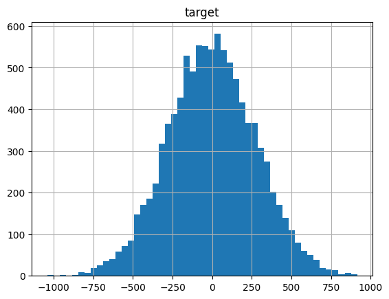

```python
df_target.hist(bins=50)
```

Целевой признак нормально распределён отнсительно 0.

Оценим параметры с помощью профайлера:

```python
dtale.show(df_features)
```

[interactive chart not shown]

ПАраметры нормально распределены, пропуски и аномалии отсутствуют.

Разделим выборку на тренировочную и тестовую:

```python
features_train, features_test, target_train, target_test = train_test_split(df_features, df_target, test_size=0.2, random_state=RANDOM_STATE)
```

Проверим наличие корреляции среди параметров:

```python
cm = sns.color_palette('vlag', as_cmap=True)
features_train.corr().style.background_gradient(cmap=cm, vmin = -1, vmax=1)
```

|  | col 0 | col 1 | col 2 | col 3 | col 4 | col 5 | col 6 | col 7 | col 8 | col 9 | col 10 | col 11 | col 12 | col 13 | col 14 | col 15 | col 16 | col 17 | col 18 | col 19 | col 20 | col 21 | col 22 | col 23 | col 24 | col 25 | col 26 | col 27 | col 28 | … |
| --- | --- | --- | --- | --- | --- | --- | --- | --- | --- | --- | --- | --- | --- | --- | --- | --- | --- | --- | --- | --- | --- | --- | --- | --- | --- | --- | --- | --- | --- | --- |
| col 0 | 1.000000 | 0.005702 | -0.012693 | -0.010917 | 0.012156 | -0.001811 | -0.003778 | -0.003688 | 0.001671 | 0.014958 | 0.002781 | 0.020613 | -0.006768 | -0.034848 | -0.013492 | 0.016563 | -0.011060 | -0.007215 | -0.004328 | 0.003219 | 0.011174 | 0.000210 | 0.025950 | 0.005648 | -0.003582 | -0.004471 | -0.017706 | -0.010319 | 0.013319 | … |
| col 1 | 0.005702 | 1.000000 | -0.000008 | -0.008126 | 0.005574 | -0.013913 | -0.001615 | -0.013717 | -0.007962 | 0.014036 | 0.006468 | 0.014299 | -0.001995 | 0.017961 | 0.016911 | -0.007211 | -0.001614 | 0.004067 | -0.011407 | 0.011755 | 0.012946 | -0.001343 | -0.002977 | 0.008290 | 0.000253 | 0.018469 | 0.002583 | -0.021026 | -0.011824 | … |
| col 2 | -0.012693 | -0.000008 | 1.000000 | -0.003995 | -0.015325 | -0.012181 | -0.009994 | -0.002224 | -0.009683 | -0.003241 | 0.018958 | -0.000099 | 0.011002 | -0.009378 | -0.004056 | -0.012086 | 0.000329 | -0.003525 | -0.000991 | 0.011615 | 0.007549 | 0.016227 | 0.002841 | 0.009969 | 0.000526 | 0.010977 | -0.004006 | 0.009746 | 0.002253 | … |
| col 3 | -0.010917 | -0.008126 | -0.003995 | 1.000000 | -0.004075 | 0.002769 | 0.012569 | -0.017624 | 0.002505 | 0.007400 | 0.010995 | 0.023273 | 0.017517 | 0.014198 | 0.018028 | 0.004875 | 0.024876 | -0.019605 | -0.001931 | 0.011118 | -0.001017 | -0.001801 | -0.014697 | -0.013502 | 0.009536 | -0.015051 | 0.002131 | -0.015888 | 0.002130 | … |
| col 4 | 0.012156 | 0.005574 | -0.015325 | -0.004075 | 1.000000 | 0.004467 | -0.020323 | -0.017145 | 0.006631 | -0.011720 | -0.000409 | 0.016990 | -0.026554 | 0.000394 | 0.012911 | 0.007624 | 0.015715 | -0.005022 | -0.009635 | 0.001575 | 0.014811 | 0.000832 | 0.002364 | 0.021229 | 0.004798 | 0.001905 | -0.016268 | 0.002123 | -0.014646 | … |
| col 5 | -0.001811 | -0.013913 | -0.012181 | 0.002769 | 0.004467 | 1.000000 | -0.002265 | 0.010933 | -0.000244 | -0.015694 | 0.002524 | 0.002984 | 0.023229 | 0.003277 | 0.017068 | -0.011897 | 0.021866 | -0.004855 | -0.008447 | -0.007534 | 0.013877 | -0.012642 | 0.008981 | -0.007646 | -0.014102 | 0.002141 | 0.003017 | -0.012748 | -0.015734 | … |
| col 6 | -0.003778 | -0.001615 | -0.009994 | 0.012569 | -0.020323 | -0.002265 | 1.000000 | -0.003810 | -0.002736 | -0.004121 | 0.013738 | 0.000751 | 0.009650 | -0.007334 | 0.010008 | -0.020056 | 0.008409 | -0.004597 | -0.002387 | -0.012517 | -0.012839 | -0.015957 | -0.008530 | 0.004956 | -0.003380 | -0.005547 | -0.006951 | -0.000547 | -0.002116 | … |
| col 7 | -0.003688 | -0.013717 | -0.002224 | -0.017624 | -0.017145 | 0.010933 | -0.003810 | 1.000000 | -0.009323 | 0.005589 | -0.007038 | -0.002000 | -0.006290 | 0.014322 | -0.016589 | 0.005746 | 0.015723 | -0.000771 | -0.002256 | 0.023211 | 0.002778 | 0.033703 | -0.004723 | -0.006790 | 0.006482 | 0.004517 | -0.000161 | 0.002847 | -0.006322 | … |
| col 8 | 0.001671 | -0.007962 | -0.009683 | 0.002505 | 0.006631 | -0.000244 | -0.002736 | -0.009323 | 1.000000 | -0.004842 | 0.002576 | -0.013215 | 0.011112 | 0.007629 | -0.000011 | -0.007660 | 0.025174 | 0.012816 | -0.007379 | 0.007048 | -0.000560 | 0.005144 | -0.002427 | 0.001438 | 0.004550 | -0.004481 | -0.003376 | 0.006549 | 0.013714 | … |
| col 9 | 0.014958 | 0.014036 | -0.003241 | 0.007400 | -0.011720 | -0.015694 | -0.004121 | 0.005589 | -0.004842 | 1.000000 | -0.010434 | -0.006852 | -0.022283 | -0.000351 | 0.008467 | -0.006171 | 0.003593 | -0.013347 | -0.017699 | 0.013051 | 0.002829 | -0.002334 | -0.010192 | -0.002002 | 0.004597 | -0.003601 | -0.014149 | -0.000206 | 0.002186 | … |
| col 10 | 0.002781 | 0.006468 | 0.018958 | 0.010995 | -0.000409 | 0.002524 | 0.013738 | -0.007038 | 0.002576 | -0.010434 | 1.000000 | -0.008572 | 0.014232 | 0.006559 | -0.017175 | 0.003393 | 0.008308 | 0.013839 | -0.005751 | -0.005033 | 0.011736 | -0.012199 | -0.005124 | -0.001478 | 0.003343 | 0.023796 | -0.002820 | 0.007917 | 0.009486 | … |
| col 11 | 0.020613 | 0.014299 | -0.000099 | 0.023273 | 0.016990 | 0.002984 | 0.000751 | -0.002000 | -0.013215 | -0.006852 | -0.008572 | 1.000000 | 0.020348 | -0.002847 | -0.003109 | -0.005591 | 0.007458 | 0.007656 | 0.002982 | 0.014928 | -0.005726 | -0.009077 | -0.002203 | -0.000452 | -0.003621 | -0.006441 | -0.005778 | -0.003270 | -0.009061 | … |
| col 12 | -0.006768 | -0.001995 | 0.011002 | 0.017517 | -0.026554 | 0.023229 | 0.009650 | -0.006290 | 0.011112 | -0.022283 | 0.014232 | 0.020348 | 1.000000 | 0.000656 | -0.007477 | 0.013389 | -0.003990 | -0.001635 | 0.016740 | 0.020783 | -0.005332 | -0.002260 | 0.012682 | 0.000415 | -0.002739 | -0.005846 | 0.000171 | 0.006554 | 0.029750 | … |
| col 13 | -0.034848 | 0.017961 | -0.009378 | 0.014198 | 0.000394 | 0.003277 | -0.007334 | 0.014322 | 0.007629 | -0.000351 | 0.006559 | -0.002847 | 0.000656 | 1.000000 | -0.017540 | 0.005671 | -0.001862 | 0.005172 | 0.010787 | 0.011419 | -0.009121 | 0.014830 | -0.007559 | -0.007025 | -0.009223 | -0.005719 | 0.016198 | -0.008850 | 0.019014 | … |
| col 14 | -0.013492 | 0.016911 | -0.004056 | 0.018028 | 0.012911 | 0.017068 | 0.010008 | -0.016589 | -0.000011 | 0.008467 | -0.017175 | -0.003109 | -0.007477 | -0.017540 | 1.000000 | 0.002545 | 0.007378 | 0.008989 | 0.006433 | 0.003345 | -0.011642 | -0.000656 | 0.004765 | 0.008216 | 0.024096 | 0.009234 | -0.002370 | 0.005419 | -0.006861 | … |
| col 15 | 0.016563 | -0.007211 | -0.012086 | 0.004875 | 0.007624 | -0.011897 | -0.020056 | 0.005746 | -0.007660 | -0.006171 | 0.003393 | -0.005591 | 0.013389 | 0.005671 | 0.002545 | 1.000000 | -0.008700 | -0.003290 | 0.005674 | -0.006897 | -0.006173 | 0.001624 | -0.011292 | 0.007017 | 0.004244 | 0.001195 | -0.010382 | -0.001839 | 0.016126 | … |
| col 16 | -0.011060 | -0.001614 | 0.000329 | 0.024876 | 0.015715 | 0.021866 | 0.008409 | 0.015723 | 0.025174 | 0.003593 | 0.008308 | 0.007458 | -0.003990 | -0.001862 | 0.007378 | -0.008700 | 1.000000 | 0.000552 | 0.010631 | 0.000331 | -0.005981 | 0.003131 | 0.000705 | 0.004029 | 0.022174 | 0.013167 | 0.006374 | -0.004504 | 0.010229 | … |
| col 17 | -0.007215 | 0.004067 | -0.003525 | -0.019605 | -0.005022 | -0.004855 | -0.004597 | -0.000771 | 0.012816 | -0.013347 | 0.013839 | 0.007656 | -0.001635 | 0.005172 | 0.008989 | -0.003290 | 0.000552 | 1.000000 | -0.005744 | 0.008638 | 0.002286 | -0.014168 | 0.014447 | 0.003654 | -0.009753 | 0.004493 | -0.006478 | 0.010097 | 0.000542 | … |
| col 18 | -0.004328 | -0.011407 | -0.000991 | -0.001931 | -0.009635 | -0.008447 | -0.002387 | -0.002256 | -0.007379 | -0.017699 | -0.005751 | 0.002982 | 0.016740 | 0.010787 | 0.006433 | 0.005674 | 0.010631 | -0.005744 | 1.000000 | 0.004341 | 0.009805 | 0.022839 | -0.011481 | -0.006236 | -0.021550 | 0.014445 | -0.000912 | -0.007896 | -0.011172 | … |
| col 19 | 0.003219 | 0.011755 | 0.011615 | 0.011118 | 0.001575 | -0.007534 | -0.012517 | 0.023211 | 0.007048 | 0.013051 | -0.005033 | 0.014928 | 0.020783 | 0.011419 | 0.003345 | -0.006897 | 0.000331 | 0.008638 | 0.004341 | 1.000000 | -0.007165 | 0.005092 | 0.004446 | -0.001959 | -0.016411 | 0.005807 | 0.014510 | 0.009060 | -0.026154 | … |
| col 20 | 0.011174 | 0.012946 | 0.007549 | -0.001017 | 0.014811 | 0.013877 | -0.012839 | 0.002778 | -0.000560 | 0.002829 | 0.011736 | -0.005726 | -0.005332 | -0.009121 | -0.011642 | -0.006173 | -0.005981 | 0.002286 | 0.009805 | -0.007165 | 1.000000 | 0.001908 | -0.008811 | -0.008281 | 0.026541 | -0.013736 | 0.004665 | 0.018833 | -0.005630 | … |
| col 21 | 0.000210 | -0.001343 | 0.016227 | -0.001801 | 0.000832 | -0.012642 | -0.015957 | 0.033703 | 0.005144 | -0.002334 | -0.012199 | -0.009077 | -0.002260 | 0.014830 | -0.000656 | 0.001624 | 0.003131 | -0.014168 | 0.022839 | 0.005092 | 0.001908 | 1.000000 | -0.003298 | 0.004898 | -0.021459 | 0.000577 | -0.016116 | -0.003049 | -0.004649 | … |
| col 22 | 0.025950 | -0.002977 | 0.002841 | -0.014697 | 0.002364 | 0.008981 | -0.008530 | -0.004723 | -0.002427 | -0.010192 | -0.005124 | -0.002203 | 0.012682 | -0.007559 | 0.004765 | -0.011292 | 0.000705 | 0.014447 | -0.011481 | 0.004446 | -0.008811 | -0.003298 | 1.000000 | 0.005460 | -0.005466 | 0.006377 | -0.003304 | 0.006012 | 0.010820 | … |
| col 23 | 0.005648 | 0.008290 | 0.009969 | -0.013502 | 0.021229 | -0.007646 | 0.004956 | -0.006790 | 0.001438 | -0.002002 | -0.001478 | -0.000452 | 0.000415 | -0.007025 | 0.008216 | 0.007017 | 0.004029 | 0.003654 | -0.006236 | -0.001959 | -0.008281 | 0.004898 | 0.005460 | 1.000000 | 0.008470 | -0.013846 | 0.005803 | 0.006660 | -0.017523 | … |
| col 24 | -0.003582 | 0.000253 | 0.000526 | 0.009536 | 0.004798 | -0.014102 | -0.003380 | 0.006482 | 0.004550 | 0.004597 | 0.003343 | -0.003621 | -0.002739 | -0.009223 | 0.024096 | 0.004244 | 0.022174 | -0.009753 | -0.021550 | -0.016411 | 0.026541 | -0.021459 | -0.005466 | 0.008470 | 1.000000 | -0.000103 | 0.002249 | -0.001471 | -0.003291 | … |
| col 25 | -0.004471 | 0.018469 | 0.010977 | -0.015051 | 0.001905 | 0.002141 | -0.005547 | 0.004517 | -0.004481 | -0.003601 | 0.023796 | -0.006441 | -0.005846 | -0.005719 | 0.009234 | 0.001195 | 0.013167 | 0.004493 | 0.014445 | 0.005807 | -0.013736 | 0.000577 | 0.006377 | -0.013846 | -0.000103 | 1.000000 | 0.011884 | -0.010892 | 0.012385 | … |
| col 26 | -0.017706 | 0.002583 | -0.004006 | 0.002131 | -0.016268 | 0.003017 | -0.006951 | -0.000161 | -0.003376 | -0.014149 | -0.002820 | -0.005778 | 0.000171 | 0.016198 | -0.002370 | -0.010382 | 0.006374 | -0.006478 | -0.000912 | 0.014510 | 0.004665 | -0.016116 | -0.003304 | 0.005803 | 0.002249 | 0.011884 | 1.000000 | 0.004094 | -0.020264 | … |
| col 27 | -0.010319 | -0.021026 | 0.009746 | -0.015888 | 0.002123 | -0.012748 | -0.000547 | 0.002847 | 0.006549 | -0.000206 | 0.007917 | -0.003270 | 0.006554 | -0.008850 | 0.005419 | -0.001839 | -0.004504 | 0.010097 | -0.007896 | 0.009060 | 0.018833 | -0.003049 | 0.006012 | 0.006660 | -0.001471 | -0.010892 | 0.004094 | 1.000000 | -0.006839 | … |
| col 28 | 0.013319 | -0.011824 | 0.002253 | 0.002130 | -0.014646 | -0.015734 | -0.002116 | -0.006322 | 0.013714 | 0.002186 | 0.009486 | -0.009061 | 0.029750 | 0.019014 | -0.006861 | 0.016126 | 0.010229 | 0.000542 | -0.011172 | -0.026154 | -0.005630 | -0.004649 | 0.010820 | -0.017523 | -0.003291 | 0.012385 | -0.020264 | -0.006839 | 1.000000 | … |
| col 29 | -0.007429 | 0.011448 | 0.002002 | 0.003487 | -0.004789 | -0.003479 | 0.031129 | 0.011879 | -0.001537 | -0.009309 | 0.013781 | 0.007034 | 0.000786 | -0.012175 | -0.011737 | -0.009500 | 0.005849 | 0.009626 | 0.010032 | 0.002197 | 0.011503 | -0.014198 | -0.003849 | 0.002744 | 0.006251 | 0.009523 | 0.003925 | -0.000606 | 0.008386 | … |

[output cut: 70 more lines]

Корреляция в признаках отсутствует, можно приступать к построению бэйслайн модели.

## Бэйслайн модель

Выделим из тренировочной выборки валидационную:

```python
X_train, X_valid, y_train, y_valid = train_test_split(features_train, target_train, test_size=0.25, random_state=RANDOM_STATE)
```

Обучим модель линейной регресии:

```python
reg = LinearRegression(n_jobs=-1).fit(X_train, y_train)
```

Получим предсказания модели:

```python
reg_preds = reg.predict(X_valid)
```

```python
reg_score = mean_squared_error(y_valid, reg_preds, squared=False)
reg_r2 = r2_score(y_valid, reg_preds)
print('RMSE модели линейной регрессии', reg_score)
print('R2 score модели линейной регрессии', reg_r2)
```

```
RMSE модели линейной регрессии 0.009818477260055516
R2 score модели линейной регрессии 0.9999999987690688
```

Обычная модель линейной регресси прекрасно справляется с предсказанием на сгенерированных данных, посмотрим можно ли улучшить этот результат с помощью более продвинутых моделей.

## Построение моделей

Построим модель Катбуст со стандартными параметрами:

```python
cat_model = CatBoostRegressor(
    random_seed=RANDOM_STATE,
    task_type="GPU",
    verbose=False
)

cat_model.fit(X_train,
              y_train,
              #cat_features = cat_features,
              eval_set=(X_valid, y_valid),
              plot=True
)
```

```
MetricVisualizer(layout=Layout(align_self='stretch', height='500px'))
```

```
<catboost.core.CatBoostRegressor at 0x2488dc7b4c0>
```

Получим предсказание модели:

```python
cat_preds = cat_model.predict(X_valid)
```

```python
cat_score = mean_squared_error(y_valid, cat_preds, squared=False)
cat_r2 = r2_score(y_valid, cat_preds)
print('RMSE модели Catboost', cat_score)
print('R2 score модели Catboost', cat_r2)
```

```
RMSE модели Catboost 43.40685221224653
R2 score модели Catboost 0.975941857809526
```

Более сложная модель Катбуст показывает худшие результаты в сравнении с обычной моделью линейной регрессии, посмотрим можно ли улучшить её результаты с помощью тюнинга гиперпараметров.

Посмтрим на важность параметров модели Катбуст:

```python
imp = cat_model.get_feature_importance(prettified=True)
imp
```

|  | Feature Id | Importances |
| --- | --- | --- |
| 0 | col 5 | 10.899424 |
| 1 | col 75 | 10.798639 |
| 2 | col 6 | 9.548907 |
| 3 | col 13 | 9.095768 |
| 4 | col 17 | 9.069701 |
| ... | ... | ... |
| 95 | col 95 | 0.000000 |
| 96 | col 96 | 0.000000 |
| 97 | col 97 | 0.000000 |
| 98 | col 98 | 0.000000 |
| 99 | col 99 | 0.000000 |

100 rows × 2 columns

```python
%matplotlib inline
plt.rcParams["figure.figsize"] = [20, 5]
```

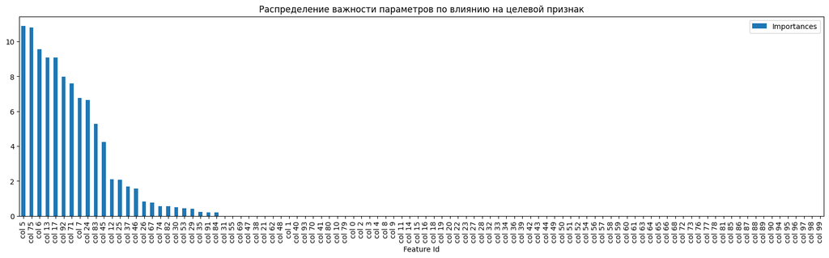

```python
imp.plot.bar(x='Feature Id', y='Importances', title='Распределение важности параметров по влиянию на целевой признак')
```

Важность большей части признаков нулевая, отсеим их для облегчения обучения модели:

```python
imp = imp[imp['Importances'] > 0.1]
```

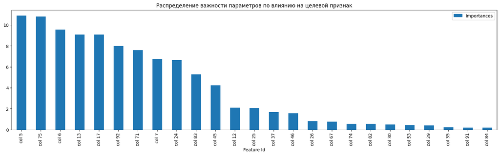

```python
imp.plot.bar(x='Feature Id', y='Importances', title='Распределение важности параметров по влиянию на целевой признак')
```

Соберём важные параметры в список:

```python
imp_features = list(imp['Feature Id'].unique())
```

Отфильтруем важные параметры в тренировочной выборке:

```python
X_train = features_train[imp_features]
y_train = target_train
```

## Оптимизация моделей с помощью optuna

Создадим вызов для сохранения лучшей модели:

```python
def callback(study, trial):
    if study.best_trial.number == trial.number:
        study.set_user_attr(key="best_booster", value=trial.user_attrs["best_booster"])
```

Зададим кросс-валидатор для моделей:

```python
cv = KFold(n_splits=5, shuffle=True, random_state=RANDOM_STATE)
```

Уберём оповещения от optuna за исключеним предупреждений:

```python
optuna.logging.set_verbosity(optuna.logging.WARNING)
```

### Catboost

Зададим сетку гиперпараметров моедели:

```python
def objective(trial):

    model = CatBoostRegressor(
        #task_type="GPU",
        iterations=trial.suggest_int("iterations", 400, 1200),
        learning_rate=trial.suggest_float("learning_rate", 1e-3, 1, log=True),
        depth=trial.suggest_int("depth", 4, 10),
        subsample=trial.suggest_float("subsample", 0.05, 1.0),
        colsample_bylevel=trial.suggest_float("colsample_bylevel", 0.05, 1.0),
        min_data_in_leaf=trial.suggest_int("min_data_in_leaf", 1, 100),
        verbose=False,
        random_seed=trial.suggest_categorical("random_seed", [RANDOM_STATE]),
    )
    trial.set_user_attr(key="best_booster", value=model)


    scores = cross_val_score(model, X_train, y_train, scoring= 'neg_root_mean_squared_error' , cv=cv, n_jobs=-1)

    return np.mean(scores)*(-1)
```

Проведём поиск гиперпараметров:

```python
cat_study = optuna.create_study(study_name="catboost", direction="minimize", sampler=TPESampler())
cat_study.optimize(objective, n_trials=100, callbacks=[callback],
                   #timeout=3600
                   )
cat_model = cat_study.user_attrs["best_booster"]
```

```python
print("Количество проведённых испытаний: ", len(cat_study.trials))
print("Лучшее испытание:")
cat_trial = cat_study.best_trial
print("  RMSE модели Catboost: ", cat_trial.value)
print("  Параметры модели Catboost: ")
for key, value in cat_trial.params.items():
    print("    {}: {}".format(key, value))
```

```
Количество проведённых испытаний:  100
Лучшее испытание:
  RMSE модели Catboost:  20.866706052706707
  Параметры модели Catboost:
    iterations: 1184
    learning_rate: 0.08232346138283328
    depth: 4
    subsample: 0.20039919681851384
    colsample_bylevel: 0.21617324273673674
    min_data_in_leaf: 49
    random_seed: 42
```

История проведенных испытаний модели Catboost:

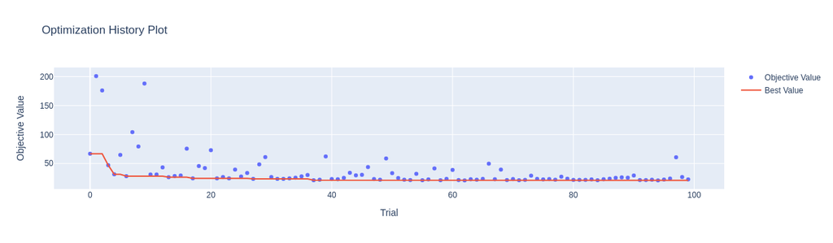

```python
optuna.visualization.plot_optimization_history(cat_study)
```

Результаты модели не стабильны и далеки от значений бэйслайн модели.

Значимость гиперапраметров модели Catboost:

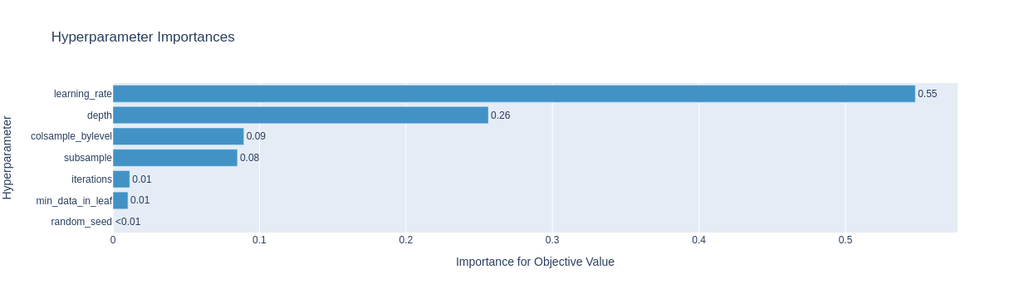

```python
optuna.visualization.plot_param_importances(cat_study)
```

Линенйные модели.

Зададим сетку гиперпараметров моделей Ridge и Lasso:

```python
def objective(trial):
    alpha = trial.suggest_float("alpha", 1e-5, 100, log=True)
    model_type = trial.suggest_categorical("model_type", ["ridge", "lasso"])

    if model_type == "ridge":
        model = Ridge(alpha=alpha, random_state=RANDOM_STATE)
    else:
        model = Lasso(alpha=alpha, random_state=RANDOM_STATE)


    trial.set_user_attr(key="best_booster", value=model)
    scores = cross_val_score(model, X_train, y_train, scoring= 'neg_root_mean_squared_error' , cv=cv, n_jobs=-1)

    return np.mean(scores)*(-1)
```

Проведём испытания:

```python
linear_study = optuna.create_study(study_name="linear", direction="minimize", sampler=TPESampler())
linear_study.optimize(objective, n_trials=100, callbacks=[callback],
                   #timeout=3600
                   )
linear_model = linear_study.user_attrs["best_booster"]
```

```python
print("Количество проведённых испытаний: ", len(linear_study.trials))
print("Лучшее испытание:")
linear_trial = linear_study.best_trial
print("  RMSE линейной модели: ", linear_trial.value)
print("  Параметры линейной модели: ")
for key, value in linear_trial.params.items():
    print("    {}: {}".format(key, value))
```

```
Количество проведённых испытаний:  100
Лучшее испытание:
  RMSE линейной модели:  0.009906905645061187
  Параметры линейной модели:
    alpha: 0.0003231200386538928
    model_type: ridge
```

Истотрия проведённых испытаний линейных моделей:

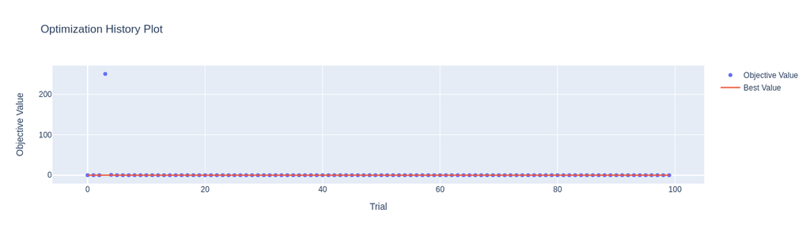

```python
optuna.visualization.plot_optimization_history(linear_study)
```

Модель быстро обучается на оличном уровне.

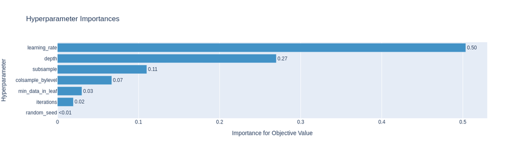

```python
optuna.visualization.plot_param_importances(cat_study)
```

### Light GBM

Зададим сетку гиперпараметров модели Light GBM:

```python
def objective(trial):

    model = LGBMRegressor(
        metric='rmse',
        random_state=RANDOM_STATE,
        n_estimators=trial.suggest_int('n_estimators', 1000, 10000),
        reg_alpha=trial.suggest_float('reg_alpha', 1e-4, 10.0,log=True),
        reg_lambda=trial.suggest_float('reg_lambda', 1e-4, 10.0,log=True),
        colsample_bytree=trial.suggest_float('colsample_bytree', 0.3, 1.0),
        subsample=trial.suggest_float('subsample', 0.5, 1.0),
        learning_rate=trial.suggest_float('learning_rate', 0.005, 0.2,log=True),
        max_depth=trial.suggest_int('max_depth', 4, 8),
        num_leaves=trial.suggest_int('num_leaves', 40, 100),
        min_child_samples=trial.suggest_int('min_child_samples', 1, 100),
        cat_smooth=trial.suggest_int('cat_smooth', 1, 100)
    )
    trial.set_user_attr(key="best_booster", value=model)


    scores = cross_val_score(model, X_train, y_train, scoring= 'neg_root_mean_squared_error' , cv=cv, n_jobs=-1)

    return np.mean(scores)*(-1)
```

Проведём испытания:

```python
optuna.logging.set_verbosity(optuna.logging.WARNING)

lgb_study = optuna.create_study(study_name="lightgbm", direction="minimize", sampler=TPESampler())
lgb_study.optimize(objective, n_trials=100, callbacks=[callback],
                   #timeout=3600
                   )
lgb_model = lgb_study.user_attrs["best_booster"]
```

```python
print("Количество проведённых испытаний: ", len(lgb_study.trials))
print("Лучшее испытание:")
lgb_trial = lgb_study.best_trial
print("  RMSE модели LightGBM: ", lgb_trial.value)
print("  Пааметры модели LightGBM: ")
for key, value in lgb_trial.params.items():
    print("    {}: {}".format(key, value))
```

```
Количество проведённых испытаний:  100
Лучшее испытание:
  RMSE модели LightGBM:  40.07846587788828
  Пааметры модели LightGBM:
    n_estimators: 8876
    reg_alpha: 0.0001315560753021979
    reg_lambda: 0.0008289163356331237
    colsample_bytree: 0.316432735296089
    subsample: 0.5108810347435867
    learning_rate: 0.03268952543919204
    max_depth: 4
    num_leaves: 49
    min_child_samples: 74
    cat_smooth: 65
```

История проведённых испытаний модели Light GBM:

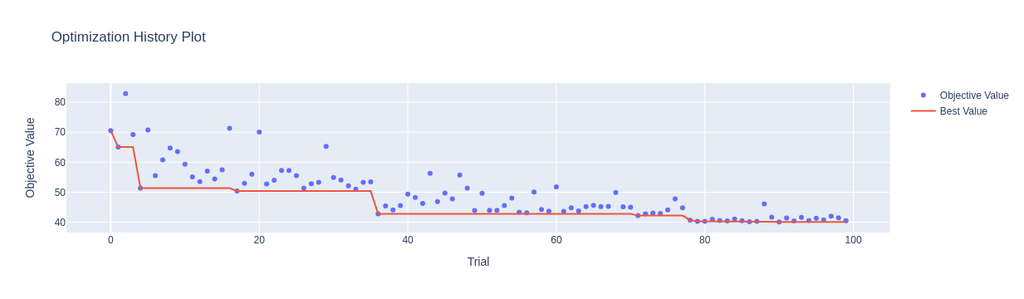

```python
optuna.visualization.plot_optimization_history(lgb_study)
```

Значимость гиперпараметров модели Light GBM:

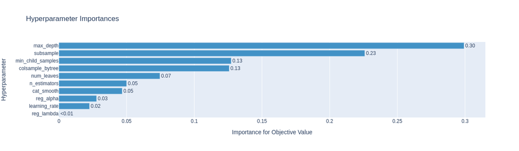

```python
optuna.visualization.plot_param_importances(lgb_study)
```

## Сравнение полученных результатов

Сведём результаты в одну таблицу:

```python
models_data = [reg_score, cat_score, cat_trial.value, linear_trial.value, lgb_trial.value]
models_df = pd.DataFrame(data=models_data,
                         index=['Linear Regression', 'default catboost regressor', 'catboost regressor w/ optuna', 'linear model w/ optuna', 'Light GBM regressor w/ optuna'],
                         columns=['RMSE на обучающей выборке']
                        )
display(models_df)
```

|  | RMSE на обучающей выборке |
| --- | --- |
| Linear Regression | 0.009818 |
| default catboost regressor | 43.406852 |
| catboost regressor w/ optuna | 20.866706 |
| linear model w/ optuna | 0.009907 |
| Light GBM regressor w/ optuna | 40.078466 |

Получается, что на сгенерированном датасете лучше всего себя показывает стандартная модель линейной регресии, а модели градиентного бустинга не дают хорошего результата несмотря на долгое обучение.

## Проверка модели на тестовой выборке

```python
test_preds = reg.predict(features_test)
test_score = mean_squared_error(target_test, test_preds, squared=False)
test_r2 = r2_score(target_test, test_preds)
print('RMSE модели линейной регрессии на тестовой выборке', test_score)
print('R2 score модели линейной регрессии на тестовой выборке', test_r2)
```

```
RMSE модели линейной регрессии на тестовой выборке 0.009982202219773783
R2 score модели линейной регрессии на тестовой выборке 0.9999999986948823
```

Модель показывает отличные результаты на тестовой выборке.